# Features and elements of multiple regression

Lesley Duff

2023-09-21

# Glossary of Terms

- *Regression*: the process of finding quantifiable relationships between “variables”, i.e. saying that we can approximate a (continuous numeric) variable by a weighted combination of other variables
- *Linear Regression*: a formula with additive weights of predictor variables
- *Explanatory/predictor/independent variables*: the variables (columns, measurements of real-world phenomena) we use to try and estimate the thing we’re interested in…
- *Outcome/response/dependet variablE (singular)*: the thing we’re trying to estimate
- *Multiple (Linear) Regression*: finding a regression using more than one explanatory/predictor/independent variables

We have data for [California Housing Prices](https://www.kaggle.com/datasets/camnugent/california-housing-prices).

“Median house prices for California districts derived from the 1990 census.”

The data contains information from the 1990 California census and pertains to the houses found in a given California district and some summary stats about them based on the 1990 census data. Columns:

- longitude
- latitude
- housing_median_age
- total_rooms
- total_bedrooms
- population
- households
- median_income
- median_house_value
- ocean_proximity

```r
library(GGally)
library(tidyverse)
# Read clean data
housing_prices <- read_csv("clean_data/housing_prices.csv")
```

## total_rooms of houses and total_bedrooms correlation?

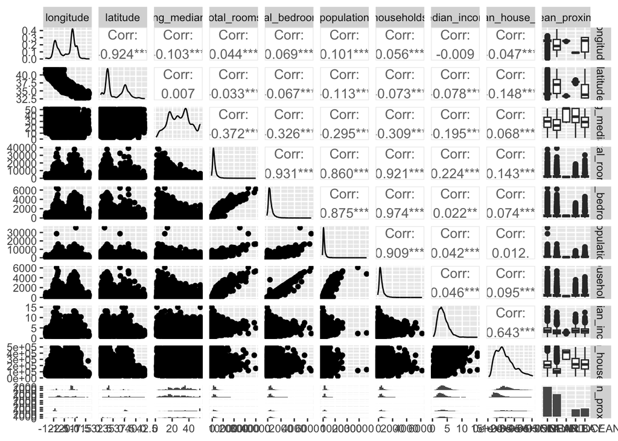

```r
# We expect the total_rooms of houses to be strongly correlated with total_bedrooms. Use ggpairs() to investigate correlations between these two variables.


ggpairs(housing_prices)
```

```r
# Check numerical correlations
housing_prices %>%
  summarise(correlation = cor(total_rooms, total_bedrooms))
```

| correlation |
| --- |
| 0.9307124 |

```r
# 0.9307124  =  very strong positive correlation
```